# 2020_Rozwiązanie_Research_Engineer - Intern_Warszawa

Twoim zadaniem jest wytrenowanie klasyfikatora binarnego na podzbiorze zbioru MNIST, w którym wyróżniamy klasy (cyfry 0 i 1 mają zostać wyłączone ze zbioru):

Napisz wydajną implementację modelu **regresji logistycznej** trenowanego algorytmem *SGD z momentum*. Cały proces trenowania musisz napisać samodzielnie, w języku Python, korzystając z biblioteki numpy. Na potrzeby zadania niedozwolone jest korzystanie z gotowych implementacji optimizerów i modeli oraz bibliotek do automatycznego różniczkowania funkcji (np. Tensorflow, pytorch, autograd).

Dobierz hiperparametry tak, aby uzyskać jak najlepszy wynik na zbiorze walidacyjnym. Wyciągnij i zapisz wnioski z przeprowadzonych eksperymentów.

Zbiór MNIST dostępny jest pod linkami:

(zbiór treningowy):

- http://yann.lecun.com/exdb/mnist/train-images-idx3-ubyte.gz
- http://yann.lecun.com/exdb/mnist/train-labels-idx1-ubyte.gz

(zbiór walidacyjny):

- http://yann.lecun.com/exdb/mnist/t10k-images-idx3-ubyte.gz
- http://yann.lecun.com/exdb/mnist/t10k-labels-idx1-ubyte.gz

# Przygotowanie danych

```python
import gzip
import numpy as np
import time
import matplotlib.pyplot as plt
```

```python
IMAGE_SIZE = 28

validation_image = gzip.open(".\\t10k-images-idx3-ubyte.gz", "r")
validation_labels = gzip.open(".\\t10k-labels-idx1-ubyte.gz", "r")

train_image = gzip.open(".\\train-images-idx3-ubyte.gz", "r")
train_labels = gzip.open(".\\train-labels-idx1-ubyte.gz", "r")

validation_image.read(16)
validation_labels.read(8)
train_image.read(16)
train_labels.read(8)

def is_prime(x):
    if x in [2,3,5,7]:
        return 1
    elif x in [4,6,8]:
        return 0
    return -1

is_prime = np.vectorize(is_prime)

def generate_matrices(buffer, length):
    M = np.frombuffer(buffer, dtype=np.uint8)
    M = M.reshape(int(M.shape[0]/(length**2)), -1)

    return M

def generate_map(labels):
    map = np.argwhere(labels == -1)
    return map.T[0]


X = generate_matrices(train_image.read(), IMAGE_SIZE)
y = is_prime(generate_matrices(train_labels.read(), 1))
map = generate_map(y)

X = np.delete(X, map, 0)
y = np.delete(y, map, 0)



v_X = generate_matrices(validation_image.read(), IMAGE_SIZE)
v_y = is_prime(generate_matrices(validation_labels.read(), 1))
map = generate_map(v_y)

v_X = np.delete(v_X, map, 0)
v_y = np.delete(v_y, map, 0)

print(X.shape)
print(y.shape)
```

```
(41386, 784)
(41386, 1)
```

# Model regresji logistycznej

W modelu wykorzystałem regularyzację l2 W celu wytrenowania modelu będę maksymalizował funkcję celu zadaną wzorem $$J(\Theta)=\frac{1}{m}\sum_{i=0}^my^{(i)}log(h_\Theta(x^{(i)})+(1-y^{(i)})log(1- h_\Theta(x^{(i)})) - \frac{\lambda}{m}\sum_{j=1}^n\Theta_j^2$$ poprzez obliczanie jej gradientu dla pojedyńczego przykładu $i$ $$\frac{d}{d\Theta_j}J(\Theta) = (y^{(i)}-h_\Theta(x^{(i)}))x_j^{(i)} - 2\lambda\Theta_j$$ W celu optymalizacji modelu używany jest SGD z momentum

### Hiperparametry strojenia modelu

- $\alpha$ - długość kroku
- $\lambda$ - współczynnik regularyzacji l2
- $epochs$ - liczba iteracji po zbiorze danych
- $\beta$ - wspołczynnik momentum ### Dodatkowe opcje
- $verbose$ - jeśli ustawiony na wartość prawdziwą program narysuje wykres zmiany funkcji kosztu po każdej iteracji

```python
class Model:
    def __init__(self, step_size = 0.1, epochs = 8, momentum = 0.9, reg =  0.00001, verbose = True):
        self.theta = np.random.rand(IMAGE_SIZE**2, 1)
        self.V = np.random.rand(IMAGE_SIZE**2, 1)
        self.step_size = step_size
        self.epochs = epochs
        self.momentum = momentum
        self.reg = reg
        self.verbose = verbose

    def __sigma(self, z):
        return 1 / (1 + np.exp(-z))

    def __cost(self, theta, X, y):
        cost = y*np.log(self.__sigma(np.matmul(X,self.theta)) + 1e-7)+(1-y)*np.log(1-self.__sigma(np.matmul(X,self.theta)) +1e-7)
        reg_cost = self.reg/2 * self.theta**2
        return cost.mean() - reg_cost.sum()/X.shape[0]


    def fit(self, X: np.ndarray, y: np.ndarray) -> None:
        y_axis = [self.__cost(self.theta, X, y)]

        start = time.time()
        iteration_start = start
        permutation = np.arange(X.shape[0])

        for epoch in range(1, self.epochs+1):
            np.random.shuffle(permutation)
            for i in permutation:
                gradient = (y[i] - self.__sigma(np.matmul(self.theta.T, X[i])))*X[i].reshape(IMAGE_SIZE**2, 1) - 2*self.reg*self.theta
                self.V = self.momentum * self.V + (1-self.momentum) * gradient
                self.theta = self.theta + self.step_size*self.V

            print(f"{epoch}/{self.epochs} iteracja zakonczona po {time.time() - iteration_start}")
            iteration_start = time.time()

            if(self.verbose == True):
                y_axis.append(self.__cost(self.theta, X, y))


        if(self.verbose == True):
            x_axis = np.arange(0, len(y_axis))
            plt.subplots()
            plt.plot(x_axis, y_axis)
            plt.title(f'epochs:{self.epochs}, step_size:{self.step_size}, momentum:{self.momentum},l2:{self.reg}')
            plt.show()

        print(f"trening zakonczony po {time.time() - start}")


    def predict(self, X: np.ndarray) -> np.ndarray:
        return self.__sigma(X@self.theta)

    @staticmethod
    def evaluate(y_true: np.ndarray, y_pred: np.ndarray) -> float:
        correct = 0
        total = 0
        for i in range(y_true.shape[0]):
            if y_true[i] == np.rint(y_pred[i]):
                correct += 1
            total += 1
        return correct/total

    def confiuson_matrix(self, y_true, y_pred):
        true_positive = true_negative = false_positive = false_negative = 0
        for i in range(y_true.shape[0]):
            if y_true[i] == np.rint(y_pred[i]) and y_true[i] == 1:
                true_positive += 1
            elif y_true[i] == np.rint(y_pred[i]) and y_true[i] == 0:
                true_negative += 1
            elif y_true[i] != np.rint(y_pred[i]) and y_true[i] == 1:
                false_negative += 1
            elif y_true[i] != np.rint(y_pred[i]) and y_true[i] == 0:
                false_positive += 1
        return true_positive, true_negative, false_positive, false_negative
```

```
1/8 iteracja zakonczona po 1.6659741401672363
2/8 iteracja zakonczona po 1.931809663772583
3/8 iteracja zakonczona po 1.9128222465515137
4/8 iteracja zakonczona po 1.943803071975708
5/8 iteracja zakonczona po 1.9328100681304932
6/8 iteracja zakonczona po 1.9268250465393066
7/8 iteracja zakonczona po 1.9118120670318604
8/8 iteracja zakonczona po 1.9268178939819336
```

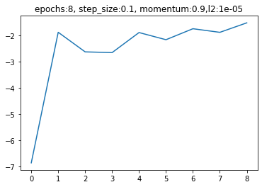

```
trening zakonczony po 15.845247030258179
0.9134671320535195
```

```python
np.random.seed(1337)
model = Model(epochs =8, step_size = 0.1, momentum = 0.9, reg = 0.00001)
model.fit(X,y)
print(model.evaluate(model.predict(v_X), v_y))
```

# Przeprowadzone eksperymenty

Wszystkie eksperymenty były przeprowadzane przy stałej wartości ziarna generatora liczb losowych wynoszącym 1337 w celu wykluczenia losowości na wpływ strojenia hiperparametrów

#### Liczba iteracji (epoch'ów)

Jak możemy zauważyć z generowanych wykresów duża ilość iteracji algorytmu ma bardzo mały wpływ na funkcjie kosztu. Algorytm w kilku pierwszych epochach osiąga już granice najwiekszej funkcji kosztów (przy odpowiednio dużym rozmiarze kroku) dla której poprawność wynosi ok. 88%, następnie oscyluje wokół niej czasami nieznacznie poprawiając maximum lecz w dużej mierze osiąga gorsze wyniki. Nie warto zatem ustawiać dużej ilości iteracji, zwłaszcza że może ona doprowadzić do przetrenowania modelu. Przkładowy wykres funkcji kosztu dla dużej ilości iteracji pokazujący oscylacje

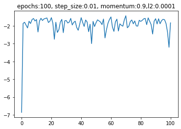

#### Długość kroku

Przy małej długości kroku algorytm nie znajduje maximum w rozsądnym czasie. Przy większych wartościach ma on wpływ na amplitude oscylacji pokazanych w punkcie powyżej.

#### Współczynnik regularyzcji l2

Przy dużych wartościach współczynnik powoduje niedouczenie modelu powodując zbyt małe dopasowanie do danych przez co model popełnia duże błędy. Pozytywny wpływ możemy zaobserwować dopiero przy bardzo małych wartościach żędu $10^{-4}$ jednak jest on bardzo mały, żędu $10^{-2}$

#### Momentum

Duży współczynnik momentum (~0.9) zancznie przyśpiesza naukę modelu, oraz zmniejsza amplitude oscylacji wokół maximum, możemy to zaobserwować na wykresach

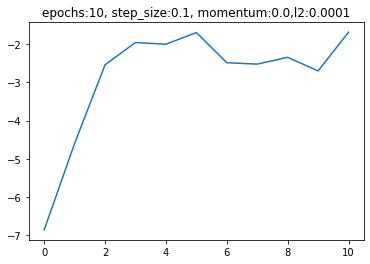

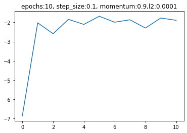

Na pierwszym obrazie wykres funkcji kosztu bez momentum, na drugim z momentum = 0.9

# Uzyskany wynik oraz wnioski

Najlepszy uzyskany przeze mnie wynik na zbiorze walidacyjnym wynosi 91% dla hiperparametrów podanych na wykresie. Są to również parametry domyślnie ustawione w konstruktorze modelu

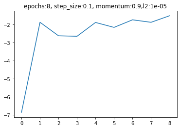

Macierz pomyłek dla wyniku

[output not shown]

Rafał Lewanczyk